# Canadian Sport Data revisions

### NGS S SUMMER

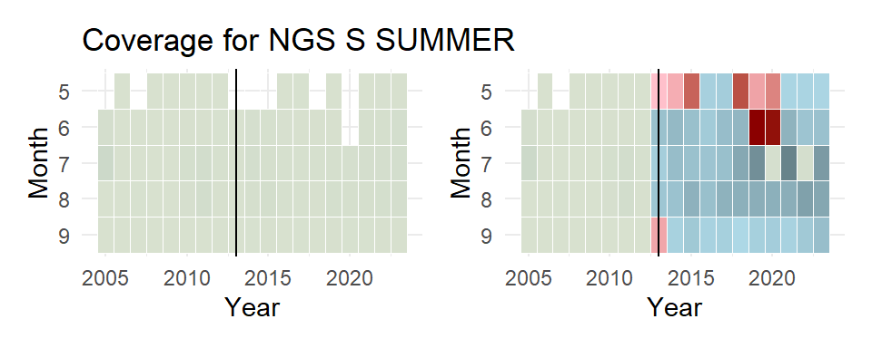

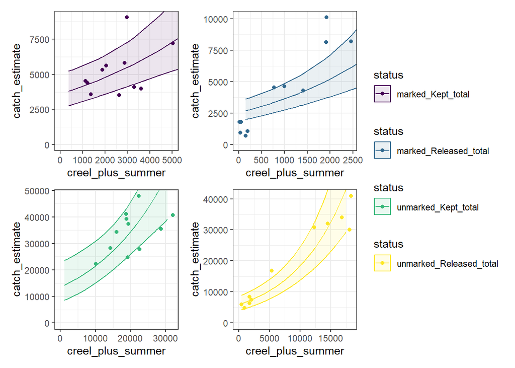

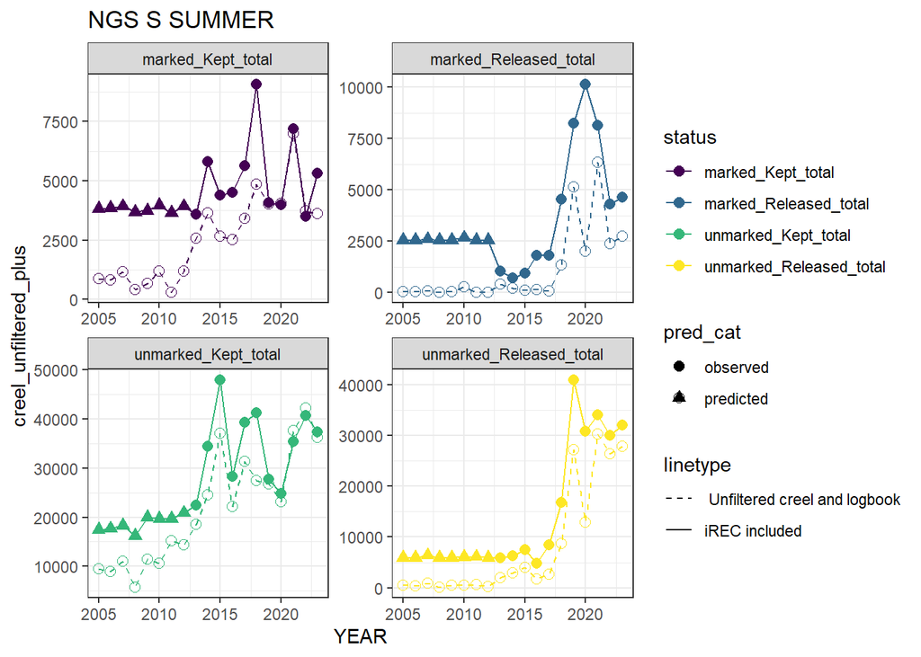

### NWCVI S SUMMER AABM

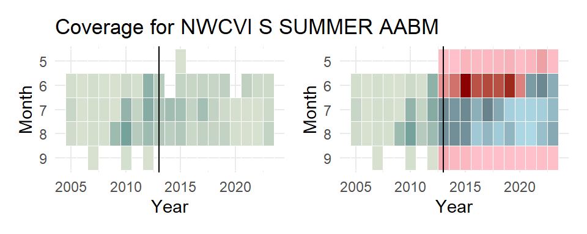

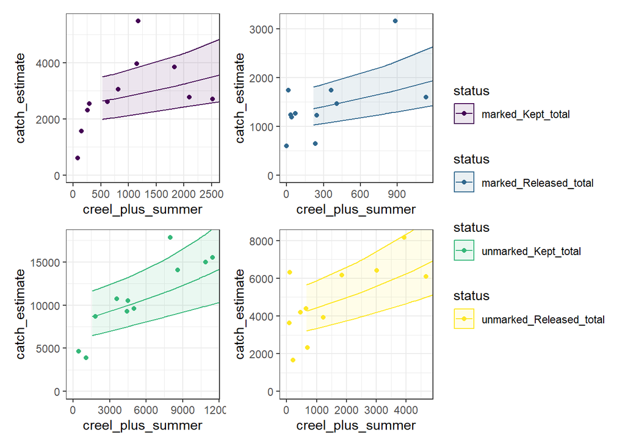

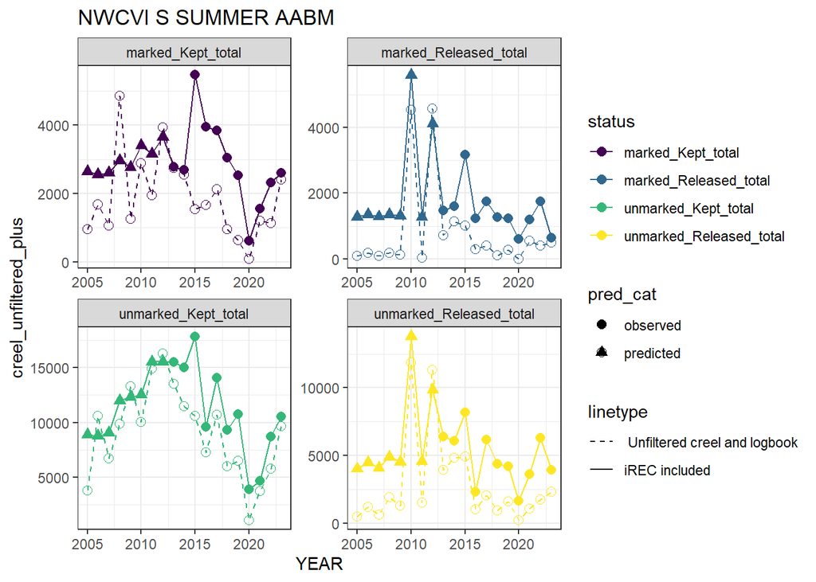

### NWCVI S SUMMER ISBM

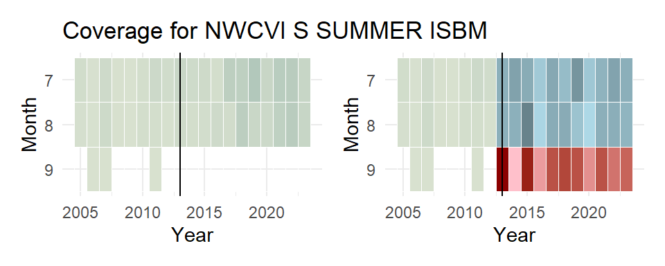

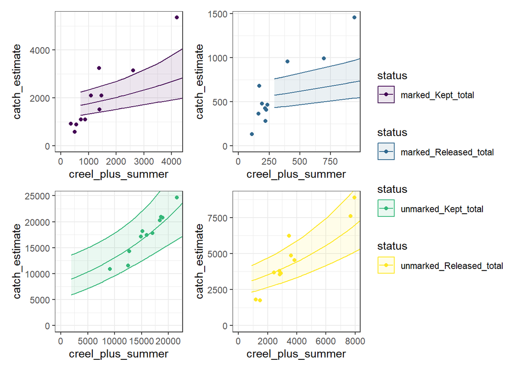

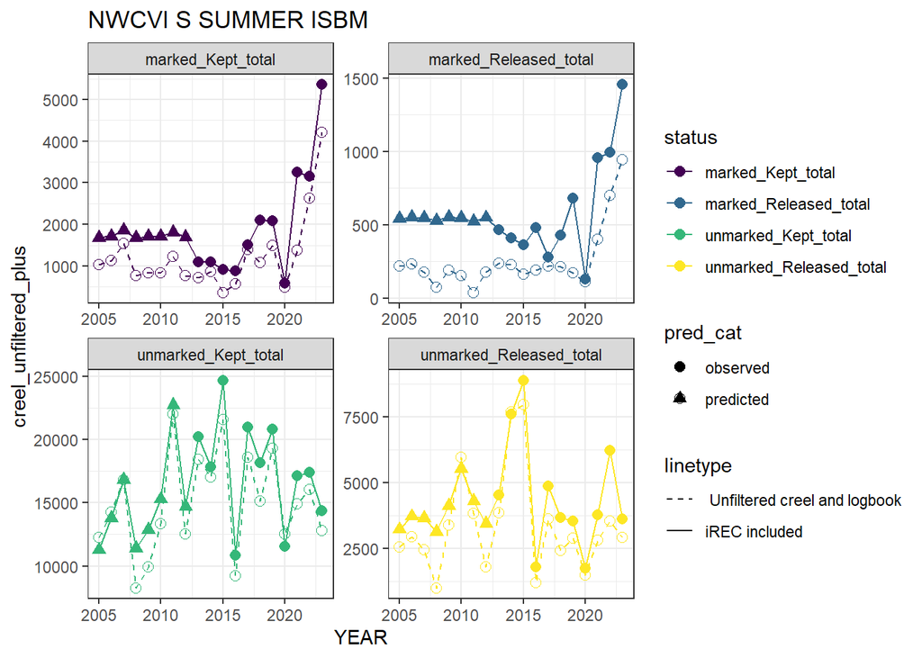

### SGS S SUMMER

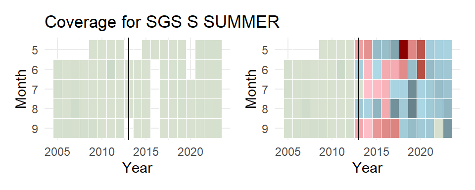

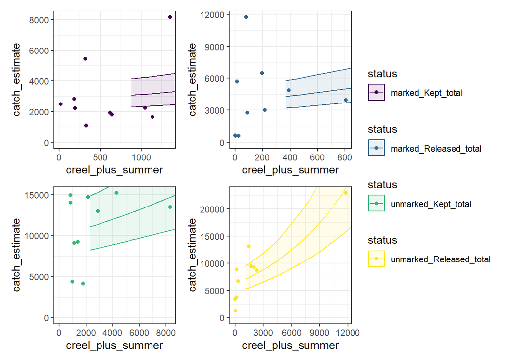

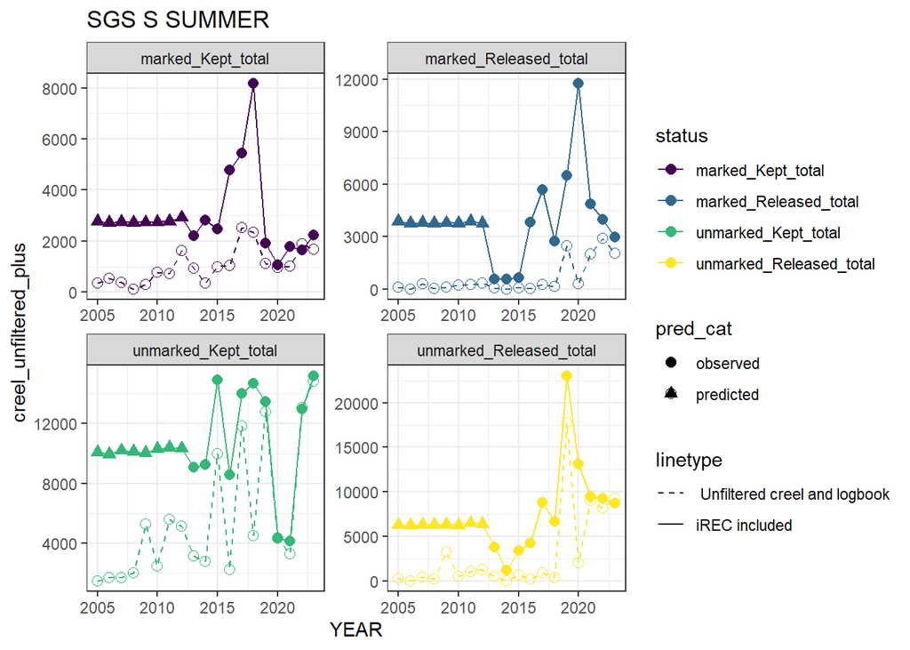

### SWCVI S SUMMER AABM

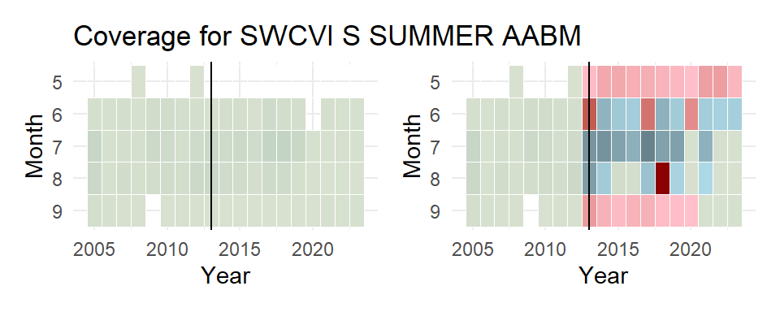

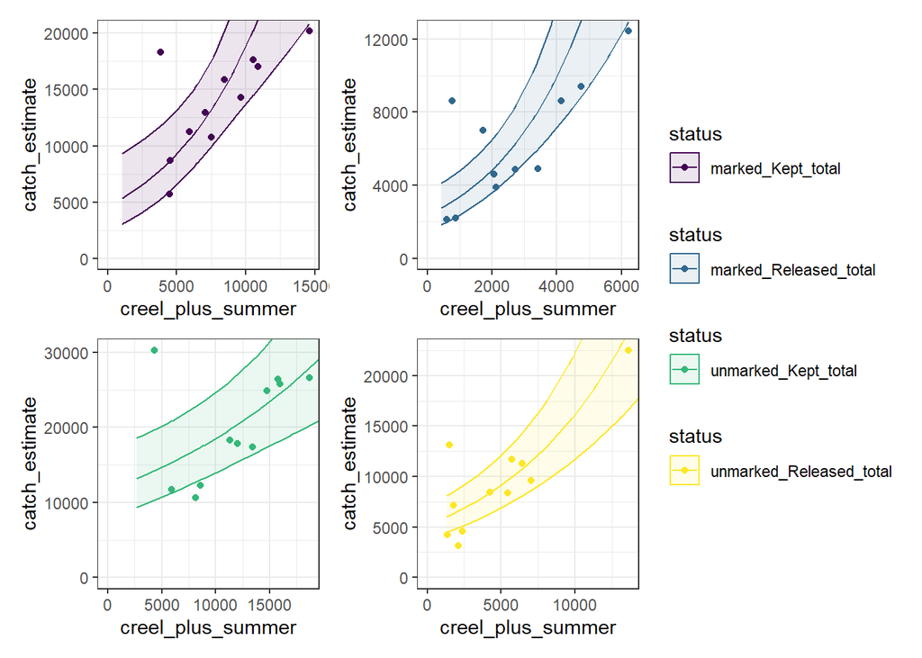

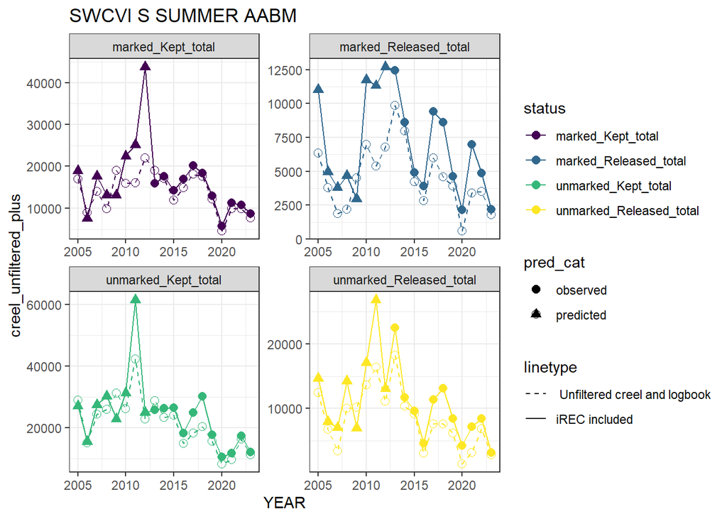

### SWCVI S SUMMER ISBM

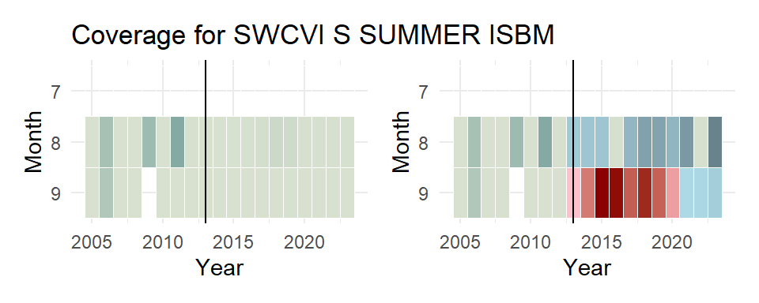

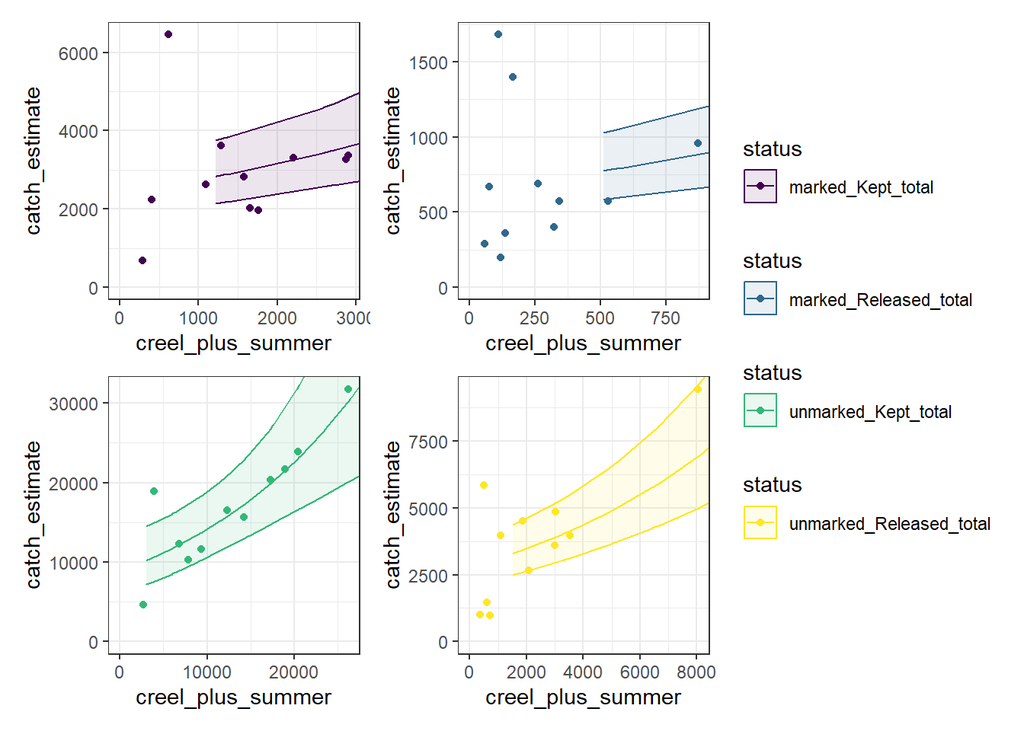

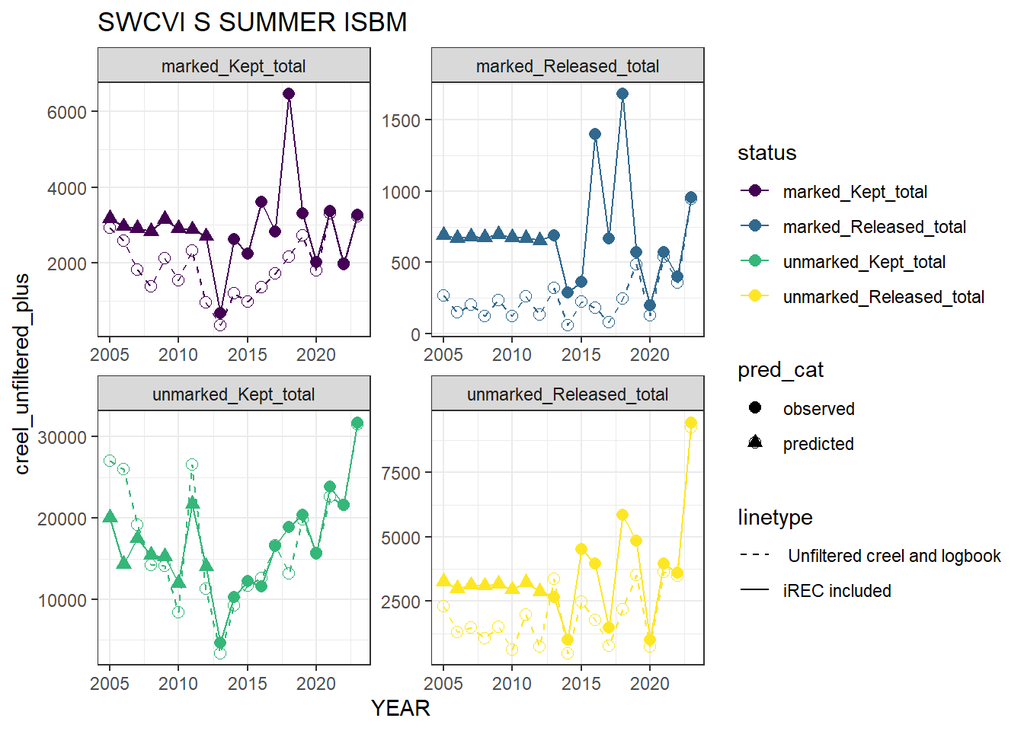

# NBC and CBC

### Methods

Northern and Central BC data is collected in different ways than South Coast. Data was in various formats and pieced together as follows:

### Northern BC - NBC AABM S

- Comprises Areas 1, 2 (East and West), 101, 102, 142
- Data for 2005 to 2008 for areas 1 and 2W found in the Fixed Sport Estimates had total unchecked (for mark status) kept and released #s of fish in the sheet QCI Sport. The sheet “ALL” has an estimate of Mark rate. Therefore:
  - Marked Kept = Unchecked Kept x mark rate
  - Marked Released = Unchecked Released x mark rate
  - Unmarked Kept = Unchecked Kept x (1- mark rate)
  - Unmarked Released = Unchecked Released x (1- mark rate)
- From 2009-2019, for Area 1, 2W, (and beginning in 2017 for 2E) there was only Unchecked Kept catch available and mark rate. Therefore we used the release rate from the Haida creel for the whole year for all of NBC AABM S to get releases.
  - Marked Kept = Unchecked Kept x mark rate
  - Marked Released = (Unchecked Kept x Release Ratio) x mark rate
  - Unmarked Kept = Unchecked Kept x (1- mark rate)
  - Unmarked Released = (Unchecked Kept x Release Ratio) x (1- mark rate)
- From 2020 to present, for Area 1, 2W, and 2E there was only Unchecked Kept and Released catch available by month and mark rate. We used mark rate from iREC to extrapolate to marked and unmarked as above (2005-2008 period).
- We modelled NBC AABM separately since the creel+ logbook data is collected in a unique way and modelled against calibrated iREC-only estimates.
- The best model included historic effort, mark status and season

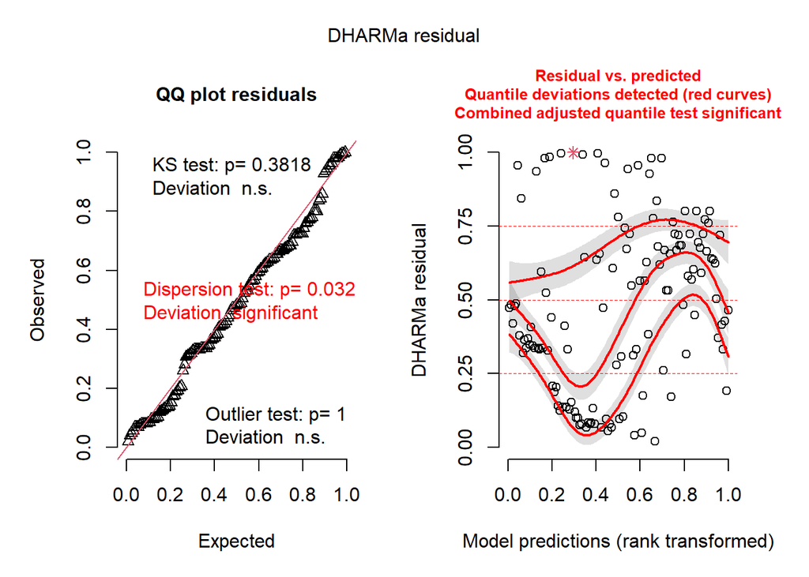

```r
Season_north_aabm<-Sport_mark_rate_finescale_combined%>% filter(YEAR %in% c(2013:2023)) %>% filter(finescale_fishery_old == "NBC AABM S")

#Modelling comparisons need to be done on models with same # of NAs - so drop nas
Season_north_aabm_no_nas<-Season_north_aabm %>% drop_na(any_of(c("historic_summer", "status", "finescale_fishery_old", "season", "historic_effort")))

North_aabm_model_full<- glm(formula = catch_estimate + 1 ~ historic_summer*status*season*historic_effort,  family=gaussian, data = Season_north_aabm_no_nas)
#summary(North_aabm_model_full)
#res <- simulateResiduals(North_aabm_model_full, plot = T, quantreg=T)

#poisson
North_aabm_model_full_poisson<- glm(formula = catch_estimate + 1 ~historic_summer*status*season*historic_effort,  family=poisson, data = Season_north_aabm_no_nas)
#res_pois <- simulateResiduals(North_aabm_model_full_poisson, plot = T, quantreg=T)
#summary(North_aabm_model_full_poisson)

#gamma
North_aabm_model_full_gamma<- glm(formula = (catch_estimate+1) ~historic_summer*status*season*historic_effort,  family=Gamma(link = "log"), data=Season_north_aabm_no_nas, na.action = na.fail)
#res_gam <- simulateResiduals(North_aabm_model_full_gamma, plot = T, quantreg=T)
#summary(North_aabm_model_full_gamma)

AICtab(North_aabm_model_full,North_aabm_model_full_poisson, North_aabm_model_full_gamma)

#gamma is the best

#Now changing around model specification:
North_aabm_model_full_gamma<- glm(formula = catch_estimate+1 ~historic_summer*season*historic_effort*status,  family=Gamma(link = "log"), data = Season_north_aabm_no_nas, na.action = na.fail)
dd<-dredge(North_aabm_model_full_gamma, fixed= ~ historic_summer)
subset(dd, delta < 2)
#plot(dd, labAsExpr = TRUE)
#
#summary(get.models(dd, 1)[[1]])

#The model with AIC <2 factors added back in:
North_aabm_model_full_gamma_spec<- glm(formula = catch_estimate+1 ~historic_summer+season+status+
                                                historic_effort*historic_summer + historic_effort*status +
                                                historic_summer*season,  family=Gamma(link = "log"), data = Season_north_aabm_no_nas)
res_gam_drop_kept_spec <- simulateResiduals(North_aabm_model_full_gamma_spec, plot = T, quantreg=T)
```

```r
#summary(North_aabm_model_full_gamma_spec)

AICtab(North_aabm_model_full_gamma, North_aabm_model_full_gamma_spec)

#Adding predicted data
Season_north_aabm_old<- Sport_mark_rate_finescale_combined %>% filter(YEAR %in% c(2005:2012)) %>% ungroup() %>% mutate(pred_cat = "predicted") %>% filter(finescale_fishery_old == "NBC AABM S")
Season_north_aabm_old_new<-predict.glm(North_aabm_model_full_gamma_spec, newdata =  Season_north_aabm_old, type = "response")
Season_north_aabm_old_new_2<-Season_north_aabm_old %>%   mutate(catch_estimate_predicted = Season_north_aabm_old_new)

Season_north_aabm2<-Season_north_aabm %>% mutate(catch_estimate_predicted = catch_estimate, pred_cat= "observed")
Season_north_aabm_combined<- rbind(Season_north_aabm_old_new_2, Season_north_aabm2)




#### Adding confidence intervals based on model to a dataframe for plotting purposes
#based on this blog: https://fromthebottomoftheheap.net/2018/12/10/confidence-intervals-for-glms/

family.set <- family(North_aabm_model_full_gamma_spec)
ilink.family.set<- family.set$linkinv

want_marked_kept <- seq(1, nrow(Season_north_aabm_no_nas %>% filter(status == "marked_Kept_total")), length.out = 1000)
want_marked_released <- seq(1, nrow(Season_north_aabm_no_nas %>% filter(status == "marked_Released_total")), length.out = 1000)
want_umarked_kept <- seq(1, nrow(Season_north_aabm_no_nas %>% filter(status == "unmarked_Kept_total")), length.out = 1000)
want_umarked_released <- seq(1, nrow(Season_north_aabm_no_nas %>% filter(status == "unmarked_Released_total")), length.out = 1000)

mod<-North_aabm_model_full_gamma_spec

ndata_marked_kept <- with(Season_north_aabm_no_nas %>% filter(status == "marked_Kept_total"), data_frame(historic_summer= seq(min(historic_summer), max(historic_summer), length = 1000),  status = "marked_Kept_total", season = season[want_marked_kept], finescale_fishery_old=finescale_fishery_old[want_marked_kept], historic_effort=historic_effort[want_marked_kept], finescale_fishery=finescale_fishery[want_marked_kept]))

ndata_marked_released <- with(Season_north_aabm_no_nas %>% filter(status == "marked_Released_total"), data_frame(historic_summer= seq(min(historic_summer), max(historic_summer), length = 1000),  status = "marked_Released_total", season = season[want_marked_released], finescale_fishery_old=finescale_fishery_old[want_marked_released], historic_effort=historic_effort[want_marked_released], finescale_fishery=finescale_fishery[want_marked_released]))

ndata_unmarked_kept <- with(Season_north_aabm_no_nas %>% filter(status == "unmarked_Kept_total"), data_frame(historic_summer= seq(min(historic_summer), max(historic_summer),length = 1000),  status = "unmarked_Kept_total", season = season[want_umarked_kept], finescale_fishery_old=finescale_fishery_old[want_umarked_kept], historic_effort=historic_effort[want_umarked_kept], finescale_fishery=finescale_fishery[want_umarked_kept]))


ndata_unmarked_released <- with(Season_north_aabm_no_nas %>% filter(status == "unmarked_Released_total"), data_frame(historic_summer= seq(min(historic_summer), max(historic_summer), length = 1000),  status =  "unmarked_Released_total", season = season[want_umarked_released], finescale_fishery_old=finescale_fishery_old[want_umarked_released], historic_effort=historic_effort[want_umarked_released], finescale_fishery=finescale_fishery[want_umarked_released]))

ndata<- bind_rows(ndata_marked_kept,ndata_marked_released, ndata_unmarked_kept, ndata_unmarked_released)

## add the fitted values by predicting from the model for the new data
ndata<- add_column(ndata, fit = predict(mod, newdata = ndata, type = 'response'))
ndata<- bind_cols(ndata, setNames(as_tibble(predict(mod, ndata, se.fit = TRUE)[1:2]),
                                                   c('fit_link','se_link')))

ndata <- mutate(ndata,
                fit_resp  = ilink.family.set(fit_link),
                right_upr = ilink.family.set(fit_link + (2 * se_link)),
                right_lwr = ilink.family.set(fit_link - (2 * se_link)))
```

```
                              dAIC   df
North_aabm_model_full_gamma      0.0 49
North_aabm_model_full         1086.8 49
North_aabm_model_full_poisson    Inf 48
Global model call: glm(formula = catch_estimate + 1 ~ historic_summer * season *
    historic_effort * status, family = Gamma(link = "log"), data = Season_north_aabm_no_nas,
    na.action = na.fail)
---
Model selection table
    (Int) hst_eff    hst_smm ssn stt hst_eff:hst_smm hst_eff:stt hst_smm:ssn df
112 2.288 -2.7830 -1.624e-04   +   +       0.0004909           +           + 15
104 1.278 -0.3099  1.673e-05   +   +                           +           + 14
7   1.295          2.029e-05   +   +                                          8
40  1.249  0.0624  1.803e-05   +   +                           +             12
71  1.169          2.215e-05   +   +                                       + 10
      logLik   AICc delta weight
112 -816.498 1667.1  0.00  0.230
104 -817.869 1667.3  0.19  0.209
7   -825.117 1667.4  0.27  0.201
40  -820.465 1667.6  0.42  0.187
71  -822.940 1667.7  0.56  0.174
Models ranked by AICc(x)
                                 dAIC df
North_aabm_model_full_gamma_spec  0.0 15
North_aabm_model_full_gamma       6.2 49
```

- forloop

### NBC AABM S FALL

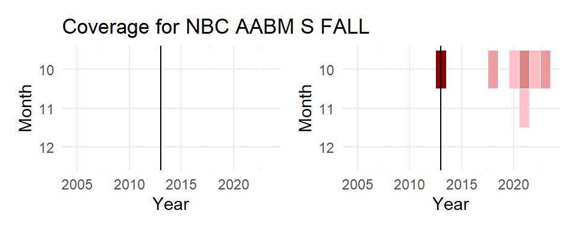

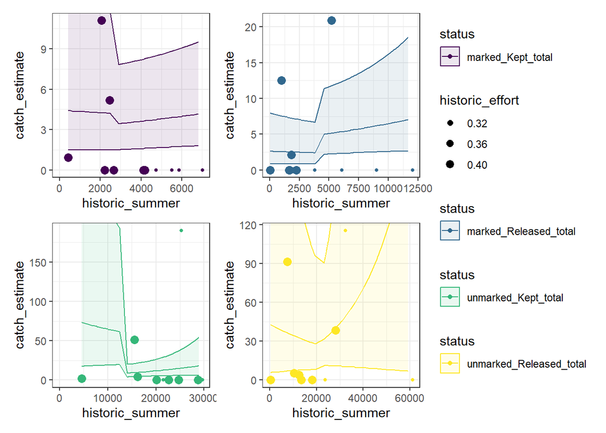

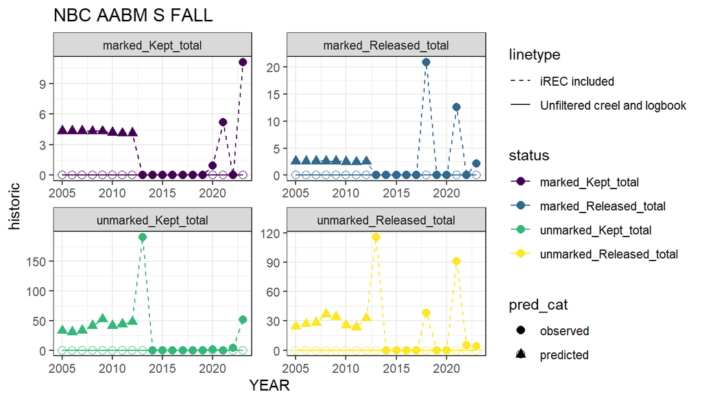

### NBC AABM S SPRING

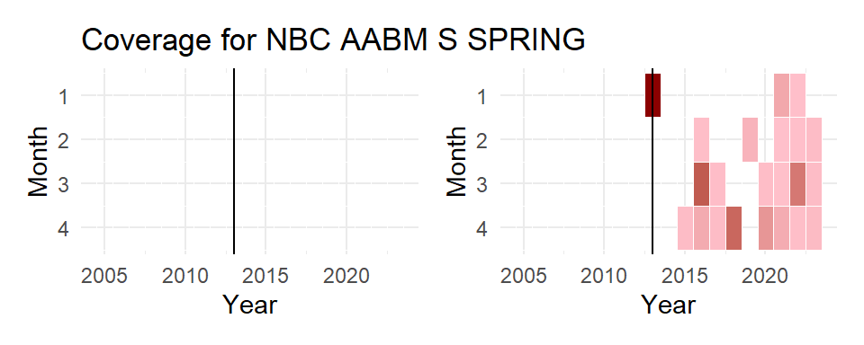

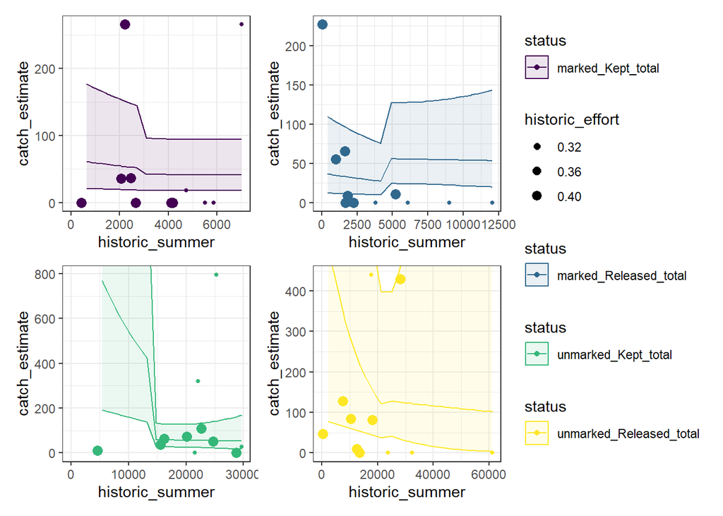

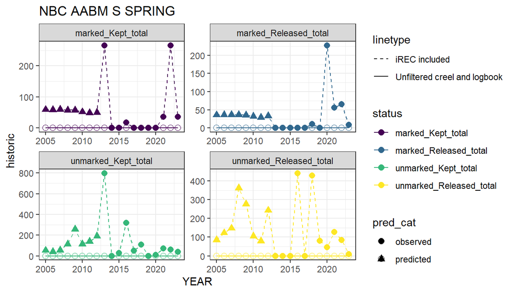

### NBC AABM S SUMMER

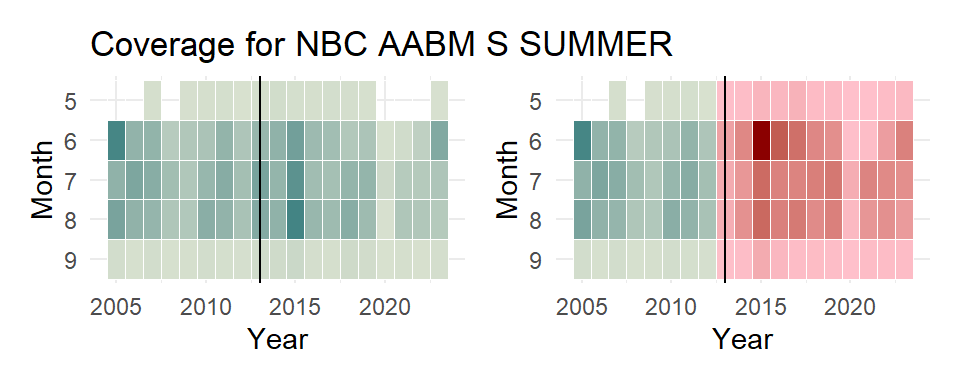

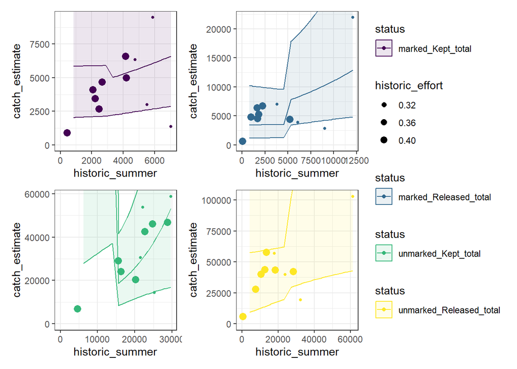

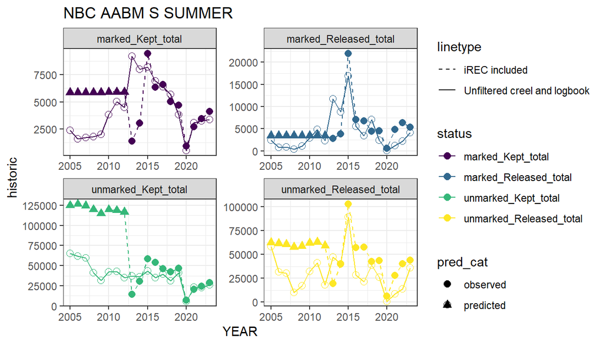

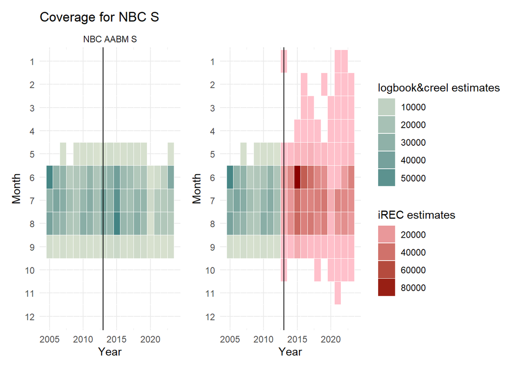

### Central BC - CBC S

- Good coverage 6:8 only, maybe 9 if omit a couple years
- irec bumps this out by a few months but not all year

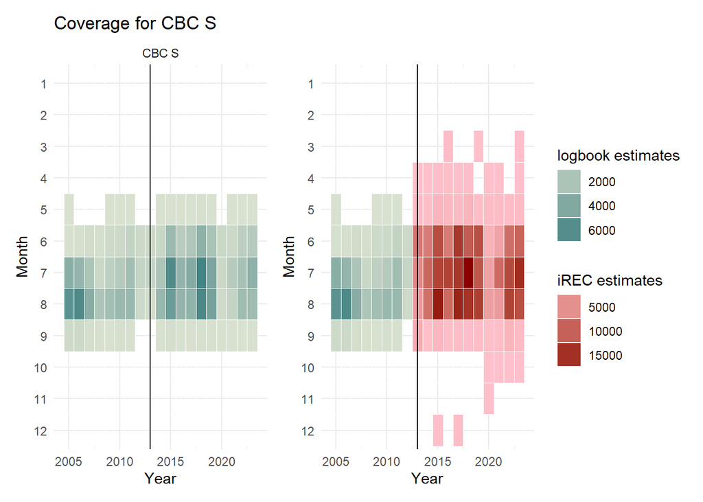

### Northern BC - NBC ISBM

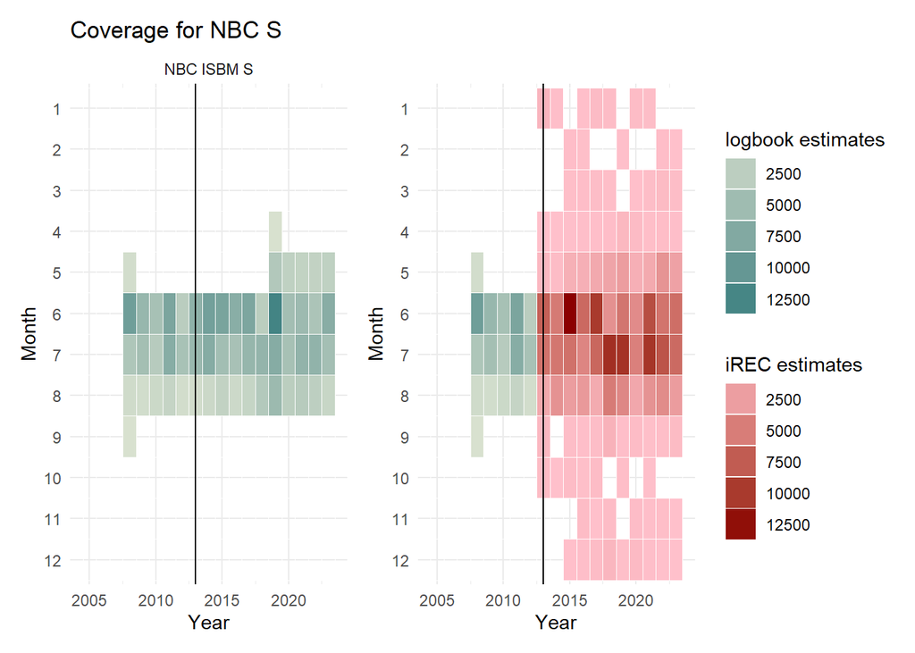